# Introduction

- Aim is to evaluate a model for MNIST classification.
- MNIST consists of handwritten digit images, with each image belonging to one of ten classes, representing digits from 0 to 9.

# Obtaining the Data

## Load the dataset & required libraries

```python
import numpy as np
import pandas as pd

# plotting modules
from matplotlib import pyplot as plt
import matplotlib.patches as patches  # for curved arrows
import seaborn as sns

# The web source of the MNIST dataset that we will work with
from sklearn.datasets import fetch_openml

# The classifiers we will use in this notebook
from sklearn.linear_model import SGDClassifier
from sklearn.dummy import DummyClassifier
from sklearn.ensemble import RandomForestClassifier

# performance metrics
from sklearn.metrics import confusion_matrix, precision_score,recall_score, f1_score, precision_recall_curve, roc_curve, roc_auc_score

# load the MNIST dataset

mnist = fetch_openml('mnist_784', as_frame=False, parser='auto')
```

## Understand more about the dataset

```python
# print the description of the dataset
print(mnist.DESCR)
```

```
**Author**: Yann LeCun, Corinna Cortes, Christopher J.C. Burges
**Source**: [MNIST Website](http://yann.lecun.com/exdb/mnist/) - Date unknown
**Please cite**:

The MNIST database of handwritten digits with 784 features, raw data available at: http://yann.lecun.com/exdb/mnist/. It can be split in a training set of the first 60,000 examples, and a test set of 10,000 examples

It is a subset of a larger set available from NIST. The digits have been size-normalized and centered in a fixed-size image. It is a good database for people who want to try learning techniques and pattern recognition methods on real-world data while spending minimal efforts on preprocessing and for…

With some classification methods (particularly template-based methods, such as SVM and K-nearest neighbors), the error rate improves when the digits are centered by bounding box rather than center of mass. If you do this kind of pre-processing, you should report it in your publications. The MNIST da…

The MNIST training set is composed of 30,000 patterns from SD-3 and 30,000 patterns from SD-1. Our test set was composed of 5,000 patterns from SD-3 and 5,000 patterns from SD-1. The 60,000 pattern training set contained examples from approximately 250 writers. We made sure that the sets of writers …

Downloaded from openml.org.
```

```python
# The dataset is a dictionary with the following keys
mnist.keys()
```

```
dict_keys(['data', 'target', 'frame', 'categories', 'feature_names', 'target_names', 'DESCR', 'details', 'url'])
```

```python
# use data and taget to access the features and the target of the dataset

X = mnist.data
y = mnist.target.astype(int)
```

## Exploratory Data Analysis

### Let's plot the first 100 images.

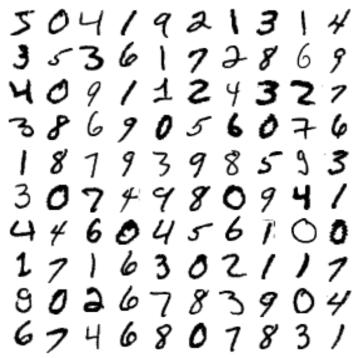

```python
def plot_digit(image_data):
    image = image_data.reshape(28, 28)
    plt.imshow(image, cmap="binary")
    plt.axis("off")

plt.figure(figsize=(9, 9))
for idx, image_data in enumerate(X[:100]):
    plt.subplot(10, 10, idx + 1)
    plot_digit(image_data)
plt.subplots_adjust(wspace=0, hspace=0)
plt.show()
```

### Let understand the class distribution : Frequency

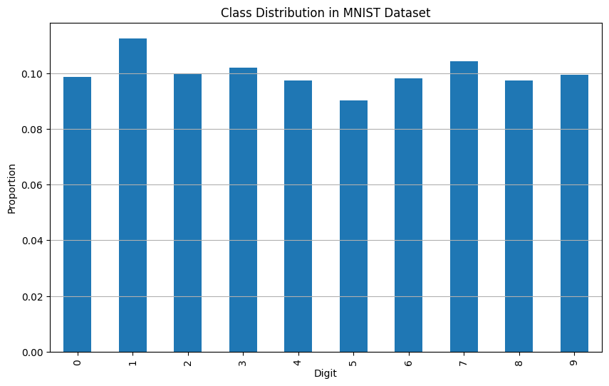

```python
# Convert the target to a pandas series to use value_counts
y_value = pd.Series(y)

# Use value_counts to get the distribution of classes
x_count = y_value.value_counts(normalize=True).sort_index()

# Plot the class distribution
plt.figure(figsize=(10, 6), facecolor='white')
x_count.plot(kind='bar')
plt.title('Class Distribution in MNIST Dataset')
plt.xlabel('Digit')
plt.ylabel('Proportion')
plt.xticks(range(0, 10))
plt.grid(axis='y')
```

## Chosing Classes & Model Selection

### Choosing number of classes

```python
from sklearn.model_selection import train_test_split

my_class = [0,1,2,3]

mask = np.isin(y, my_class)
X_filtered = X[mask]
y_filtered = y[mask]

# Split the dataset into training, validation, and test sets
X_train, X_temp, y_train, y_temp = train_test_split(X_filtered, y_filtered, test_size=0.3, random_state=42, stratify=y_filtered)
X_validation, X_test, y_validation, y_test = train_test_split(X_temp, y_temp, test_size=0.5, random_state=42)

# Print dataset sizes
print('Dataset split into train, validation, and test sets.')
print('Training set size:', X_train.shape[0])
print('Validation set size:', X_validation.shape[0])
print('Test set size:', X_test.shape[0])
```

```
Dataset split into train, validation, and test sets.
Training set size: 20237
Validation set size: 4337
Test set size: 4337
```

### Logistic Regression

```python
from sklearn.linear_model import LogisticRegression

model = LogisticRegression (multi_class='multinomial')
model.fit(X_train, y_train)
```

[output not shown]

```
LogisticRegression(multi_class='multinomial')
```

- I have taken logistic regression as my model.

[Logistic regression](https://www.kaggle.com/code/tunguz/mnist-logistic-regression-baseline)

## Model Evaluation with Validation Data

### Accuracy & Confusion Matrix

```
Accuracy of the model is 0.97
```

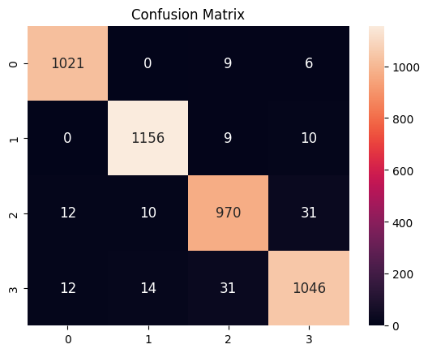

```python
from sklearn.metrics import accuracy_score, f1_score, confusion_matrix

y_pred = model.predict(X_validation)

# Accuracy
accuracy = accuracy_score(y_validation, y_pred)
print (f'Accuracy of the model is {accuracy:.2f}')

cm = confusion_matrix(y_validation, y_pred)
sns.heatmap(cm, annot=True, annot_kws={"size": 12}, fmt='d')
plt.title('Confusion Matrix')
plt. show()
```

### Precison,Recall & F1 Score for each class

```python
from sklearn.metrics import precision_score, recall_score, f1_score

prec = []
recall = []
f1= []
for i in my_class:
    # Filter predictions and  labels for the current class
    y_cls_pred = (y_pred == i)
    y_cls_true = (y_validation == i)

    # Calculate precision, recall, and F1-score for the current class
    precision_i = precision_score(y_cls_true, y_cls_pred)
    recall_i = recall_score(y_cls_true, y_cls_pred)
    f1_i = f1_score(y_cls_true, y_cls_pred)

    # appending values to list

    prec.append(precision_i)
    recall.append(recall_i)
    f1.append(f1_i)
results = {'Class': my_class, 'Precision': prec, 'Recall': recall, 'F1-score': f1}
df_results = pd.DataFrame(results)
df_results
```

|  | Class | Precision | Recall | F1-score |
| --- | --- | --- | --- | --- |
| 0 | 0 | 0.977033 | 0.985521 | 0.981259 |
| 1 | 1 | 0.979661 | 0.983830 | 0.981741 |
| 2 | 2 | 0.951914 | 0.948192 | 0.950049 |
| 3 | 3 | 0.956999 | 0.948323 | 0.952641 |

- A high precision for a class means that most of the predictions for that class were correct.
- High recall means that the class was correctly recognized a high percentage of the time.
- A high F1-score means that the model has a good balance between precision and recall for that class.
- Class 0 and 1 have good value of precision,recall and F1-score.
- Class 1 has high precision(0.979661),and recall is almost similiar with class 0.
- Class 1 have good balances between precision and recall as it have high value of F1-score.

### Precision-Recall Curve

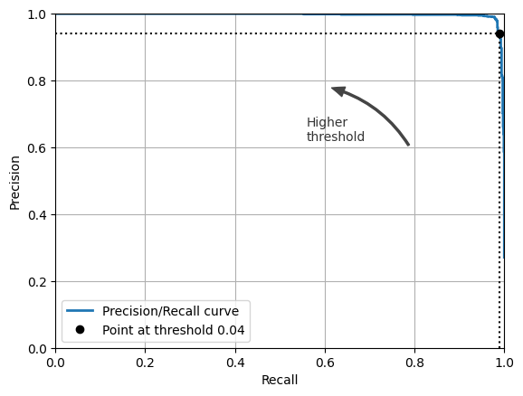

```python
from sklearn.metrics import precision_recall_curve
import matplotlib.pyplot as plt

# I have selected class 1
class_number = 1

# creat binary array for the class
classifiers = (y_validation == class_number).astype(int)
precision, recall, thresholds = precision_recall_curve(classifiers, model.predict_proba(X_validation)[:, class_number])

# Plot precision-recall curve
plt.plot(recall, precision, linewidth=2, label="Precision/Recall curve")

idx = 3100   ### random index
plt.plot([recall[idx], recall[idx]], [0., precision[idx]], "k:")
plt.plot([0.0, recall[idx]], [precision[idx], precision[idx]], "k:")
plt.plot([recall[idx]], [precision[idx]], "ko", label=f"Point at threshold {thresholds[idx]:.2f}")

# plot the point of the threshold
plt.gca().add_patch(patches.FancyArrowPatch(
    (0.79, 0.60), (0.61, 0.78),
    connectionstyle="arc3,rad=.2",
    arrowstyle="Simple, tail_width=1.5, head_width=8, head_length=10",
    color="#444444"))
plt.text(0.56, 0.62, "Higher\nthreshold", color="#333333")

# Add labels and legend
plt.xlabel("Recall")
plt.ylabel("Precision")
plt.axis([0, 1, 0, 1])
plt.grid()
plt.legend(loc="lower left")
plt.show()
```

## Increase Precision

```python
y_true = [0, 0, 0, 1, 1, 1, 2, 2, 2]  # Actual classes
y_pred_probs = [0.9, 0.8, 0.7, 0.6, 0.5, 0.4, 0.3, 0.2, 0.1]  # Predicted probabilities for class 1

# Original decision threshold
threshold = 0.5

# Function to adjust predictions based on a new threshold
def adjust_predictions(y_pred_probs, threshold):
    return [1 if prob >= threshold else 0 for prob in y_pred_probs]

# Adjusting threshold to increase precision for class 1
new_threshold = 0.75  # Increase threshold
y_pred_adjusted = adjust_predictions(y_pred_probs, new_threshold)

from sklearn.metrics import precision_score, recall_score, f1_score

# Calculate new precision, recall, and F1-score
precision = precision_score(y_true, y_pred_adjusted, average='macro', zero_division=0)
recall = recall_score(y_true, y_pred_adjusted, average='macro', zero_division=0)
f1 = f1_score(y_true, y_pred_adjusted, average='macro', zero_division=0)

print(f"New Precision: {precision}")
print(f"New Recall: {recall}")
print(f"New F1-score: {f1}")
```

```
New Precision: 0.047619047619047616
New Recall: 0.1111111111111111
New F1-score: 0.06666666666666667
```

## Test Data Evaluation

```
Accuracy of the model is 0.97
```

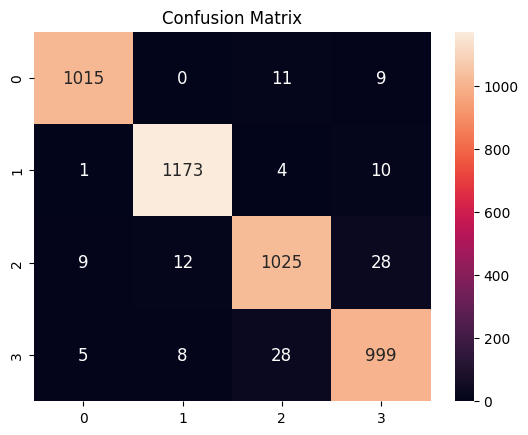

```
[[1015    0   11    9]
 [   1 1173    4   10]
 [   9   12 1025   28]
 [   5    8   28  999]]
```

```python
y_pred_test = model.predict(X_test)

# Accuracy
accuracy = accuracy_score(y_test, y_pred_test)
print (f'Accuracy of the model is {accuracy:.2f}')

cm = confusion_matrix(y_test, y_pred_test)
sns.heatmap(cm, annot=True, annot_kws={"size": 12}, fmt='d')
plt.title('Confusion Matrix')
plt. show()

print(cm)
```